# Data Science Capstone Project - Milestone Report

Otavio Cals

April 29, 2016

# Introduction

In this publication we report our progress so far into the Johns Hopkins’ Data Science Capstone Project. We will present here the data shared by SwiftKey, perform a quick analysis on it and briefly describes our goal for the eventual app for the final project.

# Loading the Data

First, we will load the SwiftKey Data. For this project, Swiftkey has shared text datasets from Twitter, blogposts and newsposts, available in English, German, Finnish and Russian. For this report, we shall focus on the english version of the data.

```r
news  <-  readLines("../Datasets/en_US/en_US.news.txt", encoding="UTF-8")
twitter  <-  readLines("../Datasets/en_US/en_US.twitter.txt", encoding="UTF-8")
blogs  <-  readLines("../Datasets/en_US/en_US.blogs.txt", encoding="UTF-8")
```

Now we print the first lines of each dataset to verify that they were properly loaded.

```r
head(news,3)
```

```
## [1] "He wasn't home alone, apparently."
## [2] "The St. Louis plant had to close. It would die of old age. Workers had been making cars there since the onset of mass automotive production in the 1920s."
## [3] "WSU's plans quickly became a hot topic on local online sites. Though most people applauded plans for the new biomedical center, many deplored the potential loss of the building."
```

```r
head(twitter,3)
```

```
## [1] "How are you? Btw thanks for the RT. You gonna be in DC anytime soon? Love to see you. Been way, way too long."
## [2] "When you meet someone special... you'll know. Your heart will beat more rapidly and you'll smile for no reason."
## [3] "they've decided its more fun if I don't."
```

```r
head(blogs,3)
```

```
## [1] "In the years thereafter, most of the Oil fields and platforms were named after pagan gods."
## [2] "We love you Mr. Brown."
## [3] "Chad has been awesome with the kids and holding down the fort while I work later than usual! The kids have been busy together playing Skylander on the XBox together, after Kyan cashed in his $$$ from his piggy bank. He wanted that game so bad and used his gift card from his birthday he has b…
```

# Data Analysis

Here we will perform some brief data analysis on the datasets. We begin by getting a summary of them. The Length variable indicates the amount of lines in the dataset.

```r
summary(news)
```

```
##    Length     Class      Mode
##     77259 character character
```

```r
summary(twitter)
```

```
##    Length     Class      Mode
##   2360148 character character
```

```r
summary(blogs)
```

```
##    Length     Class      Mode
##    899288 character character
```

Now, some word count on the datasets. For this task, we will use the stringi library.  
The Words variable indicates the total number of words, the CharsWord indicate the total number of characters and the CharsWhite indicate the total number of whitespaces.

```r
require(stringi)

stri_stats_latex(news)[c(4,1,3)]
```

```
##      Words  CharsWord CharsWhite
##    2651432   12476453    3096618
```

```r
stri_stats_latex(twitter)[c(4,1,3)]
```

```
##      Words  CharsWord CharsWhite
##   30451128  125570616   35958481
```

```r
stri_stats_latex(blogs)[c(4,1,3)]
```

```
##      Words  CharsWord CharsWhite
##   37570839  162464653   42636700
```

Next, we will perform a word frequency count. For that, we have written three R scripts:

- tokenize(): for tokenization of the text;
- filter_tokens(): for common words filtering;
- aggregator(): for frequency analysis.

Since this step is quite computation heavy and the scripts are not yet optimized, we will run then only on a subset of the datasets and will print only the 10 most frequent words in each dataset after the filtering.

```r
source("../Scripts/tokenize.R")
source("../Scripts/filter_tokens.R")
source("../Scripts/aggregator.R")

token_news <- tokenize(news[1:1000])
token_twitter <- tokenize(twitter[1:1000])
token_blogs <- tokenize(blogs[1:1000])

common_words <- stopwords("english")

filtered_news <- filter_tokens(token_news,common_words)
filtered_twitter <- filter_tokens(token_twitter,common_words)
filtered_blogs <- filter_tokens(token_blogs,common_words)

freq_news <- aggregator(filtered_news)
freq_twitter <- aggregator(filtered_twitter)
freq_blogs <- aggregator(filtered_blogs)

head(freq_news,10)
```

```
##      Var1 Freq
## 214  said  259
## 111  will  106
## 28   year   96
## 421   new   80
## 357   one   73
## 193   two   70
## 116 first   64
## 671  just   59
## 410   can   57
## 39   like   55
```

```r
head(freq_twitter,10)
```

```
##     Var1 Freq
## 176  can   69
## 265 just   62
## 117 like   58
## 94   one   53
## 92  love   48
## 30  know   46
## 114  day   44
## 24   don   42
## 235  get   40
## 33  will   37
```

```r
head(freq_blogs,10)
```

```
##     Var1 Freq
## 34   one  150
## 101 like  142
## 10   can  135
## 70  just  131
## 54  will  117
## 88  time  114
## 273  get   88
## 336 know   74
## 377  day   73
## 419  new   72
```

To end the analysis, we make a barplot of the most frequent words, we have:

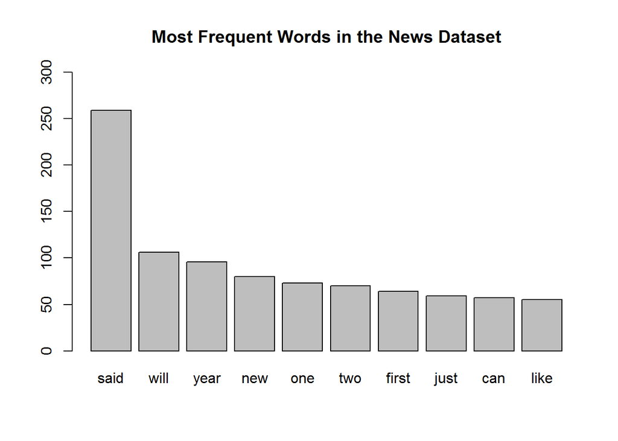

```r
barplot(head(freq_news,10)[,2],names.arg = head(freq_news,10)[,1],ylim=c(0,300),main = "Most Frequent Words in the News Dataset")
```

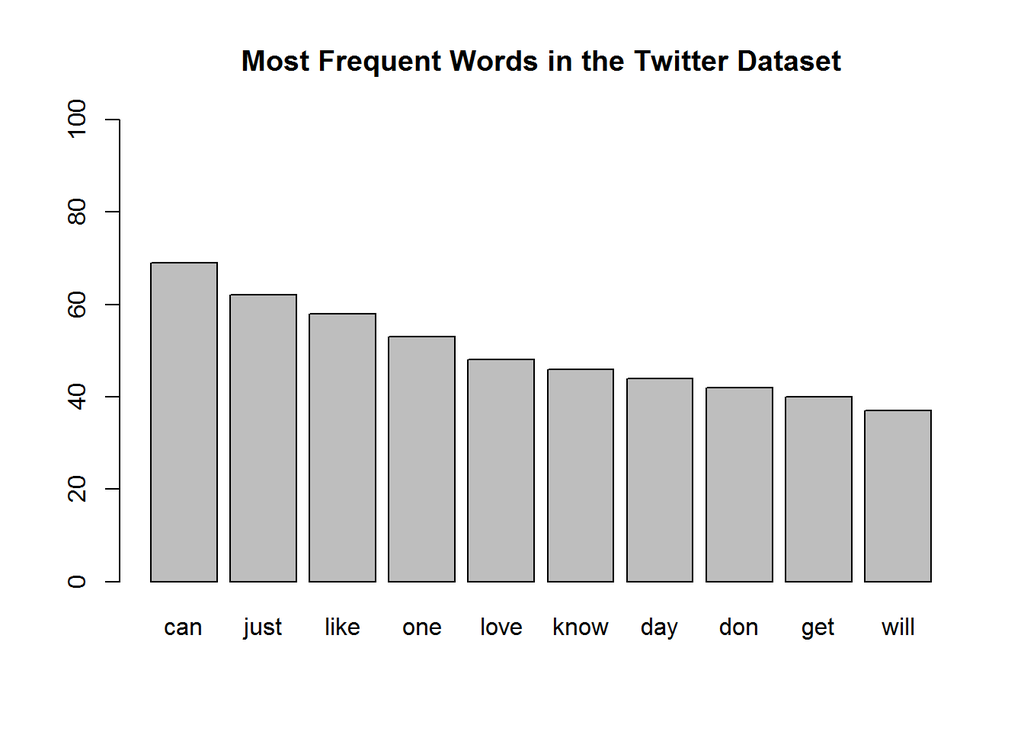

```r
barplot(head(freq_twitter,10)[,2],names.arg = head(freq_twitter,10)[,1],ylim=c(0,100),main = "Most Frequent Words in the Twitter Dataset")
```

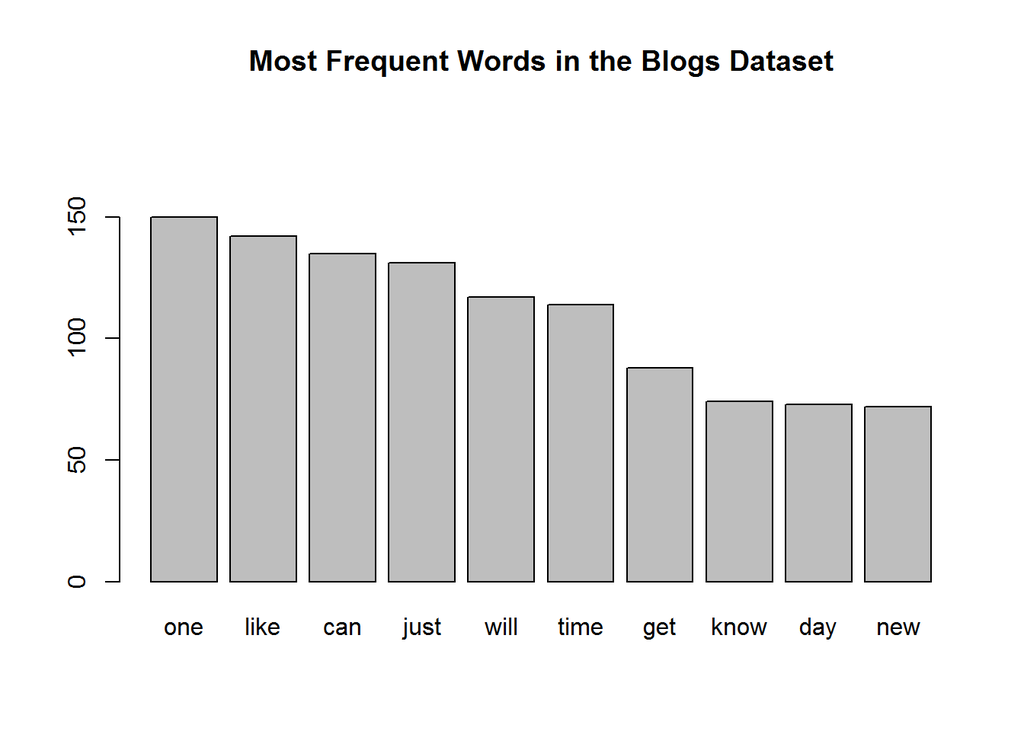

```r
barplot(head(freq_blogs,10)[,2],names.arg = head(freq_blogs,10)[,1],ylim=c(0,190),main = "Most Frequent Words in the Blogs Dataset")
```

# Final Project

Our goal for the final project is to use the previous frequency analysis method, in an iterative fashion, to trace the words with the highest correlation to a specific, target word.  
After that, we plan to create a “Correlation Density Map” of that target word, allowing us to measure the breadth of a specific subject (in this case, the target word). A word with a highly concentrated CDM over a few related words would indicate a low-breadth subject, while a word with a low concentration over a vast set of words would indicate a high-breadth subject.  
One could then apply this routine, in areas such as social media and news reporting, to perform more focused searches and better distribute content.